> **Hint**: Welcome to (Introduction to Data Science) project You will find some Notes in quoted sections like this to help organize your project for submission. First things, you might want to double-click this cell and change the title so that it reflects your dataset and your Work.

# Data Science Project 2025:clean ,visualize, make Desriptive Statistics,and also Answer your Questions about Data (High School Student Performance)

Names: Fathy Medhat AbdRabbuh 20251577022 Hazem Mohamed Saadeldin 20251578210 Ahmed Mohamed Ahmed Yehia 20251577002 Hashm Hamdii Ramadan 20251578552

## Steps that you should follow

- Dataset Information
- Gathering
- Assessing
- Data Wrangling
- Exploratory Data Analysis
- Type Comment for Every Graph or Plot
- Conclusions

## Introduction

> In this section of the report, provide a brief introduction to the dataset you've selected for analysis. At the end of this section, describe the questions that you plan on exploring over the course of the report. Try to build your report around the analysis of at least one dependent variable and three independent variables. If you're not sure what questions to ask, then make sure you familiarize yourself with the dataset, its variables and the dataset context for ideas of what to explore.

```python
import pandas as pd
```

```python
import numpy as np
```

```python
import matplotlib.pyplot as plt
```

```python
import seaborn as sns
```

## Data Wrangling

> In this section of the report, you will load in the data, check for cleanliness, and then trim and clean your dataset for analysis. Make sure that you document your steps carefully and justify your cleaning decisions.

### General Properties

```python
df = pd.read_csv('High School Student Performance.csv')
```

```python
df.head()
```

|  | student_id | school | sex | age | address_type | family_size | parent_status | mother_education | father_education | mother_job | ... | family_relationship | free_time | social | weekday_alcohol | weekend_alcohol | health | absences | grade_1 | grade_2 | final_grade |
| --- | --- | --- | --- | --- | --- | --- | --- | --- | --- | --- | --- | --- | --- | --- | --- | --- | --- | --- | --- | --- | --- |
| 0 | 14 | GP | M | 15 | Urban | Greater than 3 | Living together | higher education | secondary education | teacher | ... | 5 | 4 | 3 | 1 | 2 | 3 | 2 | 10 | 10 | 11 |
| 1 | 15 | GP | M | 15 | Urban | Greater than 3 | Apart | 5th to 9th grade | 5th to 9th grade | other | ... | 4 | 5 | 2 | 1 | 1 | 3 | 0 | 14 | 16 | 16 |
| 2 | 16 | GP | F | 16 | Urban | Greater than 3 | Living together | higher education | higher education | health | ... | 4 | 4 | 4 | 1 | 2 | 2 | 4 | 14 | 14 | 14 |
| 3 | 17 | GP | F | 16 | Urban | Greater than 3 | Living together | higher education | higher education | services | ... | 3 | 2 | 3 | 1 | 2 | 2 | 6 | 13 | 14 | 14 |
| 4 | 18 | GP | F | 16 | Urban | Greater than 3 | Living together | secondary education | secondary education | other | ... | 5 | 3 | 2 | 1 | 1 | 4 | 4 | 8 | 10 | 10 |

5 rows × 34 columns

```python
df.shape #302 rows ,34 Columns
```

```
(302, 34)
```

```python
df.info()
```

```
<class 'pandas.core.frame.DataFrame'>
RangeIndex: 302 entries, 0 to 301
Data columns (total 34 columns):
 #   Column                 Non-Null Count  Dtype
---  ------                 --------------  -----
 0   student_id             302 non-null    int64
 1   school                 302 non-null    object
 2   sex                    302 non-null    object
 3   age                    302 non-null    int64
 4   address_type           302 non-null    object
 5   family_size            302 non-null    object
 6   parent_status          302 non-null    object
 7   mother_education       302 non-null    object
 8   father_education       302 non-null    object
 9   mother_job             302 non-null    object
```

[output cut: 26 more lines]

```python
df.describe()
```

|  | student_id | age | class_failures | family_relationship | free_time | social | weekday_alcohol | weekend_alcohol | health | absences | grade_1 | grade_2 | final_grade |
| --- | --- | --- | --- | --- | --- | --- | --- | --- | --- | --- | --- | --- | --- |
| count | 302.000000 | 302.000000 | 302.000000 | 302.000000 | 302.000000 | 302.000000 | 302.000000 | 302.000000 | 302.000000 | 302.000000 | 302.000000 | 302.000000 | 302.000000 |
| mean | 164.500000 | 16.430464 | 0.341060 | 3.930464 | 3.231788 | 3.115894 | 1.447020 | 2.271523 | 3.576159 | 6.079470 | 10.903974 | 10.728477 | 10.536424 |
| std | 87.324109 | 1.206350 | 0.760029 | 0.903187 | 1.007900 | 1.136737 | 0.871575 | 1.334111 | 1.385435 | 8.516174 | 3.347144 | 3.861272 | 4.535244 |
| min | 14.000000 | 15.000000 | 0.000000 | 1.000000 | 1.000000 | 1.000000 | 1.000000 | 1.000000 | 1.000000 | 0.000000 | 3.000000 | 0.000000 | 0.000000 |
| 25% | 89.250000 | 16.000000 | 0.000000 | 4.000000 | 3.000000 | 2.000000 | 1.000000 | 1.000000 | 3.000000 | 0.000000 | 8.000000 | 9.000000 | 8.000000 |
| 50% | 164.500000 | 16.000000 | 0.000000 | 4.000000 | 3.000000 | 3.000000 | 1.000000 | 2.000000 | 4.000000 | 4.000000 | 11.000000 | 11.000000 | 11.000000 |
| 75% | 239.750000 | 17.000000 | 0.000000 | 5.000000 | 4.000000 | 4.000000 | 2.000000 | 3.000000 | 5.000000 | 8.000000 | 13.000000 | 13.000000 | 14.000000 |
| max | 315.000000 | 22.000000 | 3.000000 | 5.000000 | 5.000000 | 5.000000 | 5.000000 | 5.000000 | 5.000000 | 75.000000 | 19.000000 | 19.000000 | 20.000000 |

> **Note that**: You should *not* perform too many operations in each cell. Create cells freely to explore your data. One option that you can take with this project is to do a lot of explorations in an initial notebook. These don't have to be organized, but make sure you use enough comments to understand the purpose of each code cell.

> Make sure that you keep your reader informed on the steps that you are taking in your Analysis and Visualization.

### Data Cleaning (Remove Missing Values ,NaN , null Values & Outliers)

```python
df.isnull().sum() #التأكد من القيم المفقودة (NaN / Null)
```

```
student_id               0
school                   0
sex                      0
age                      0
address_type             0
family_size              0
parent_status            0
mother_education         0
father_education         0
mother_job               0
father_job               0
school_choice_reason     0
guardian                 0
travel_time              0
study_time               0
class_failures           0
school_support           0
family_support           0
extra_paid_classes       0
activities               0
nursery_school           0
higher_ed                0
internet_access          0
romantic_relationship    0
family_relationship      0
free_time                0
social                   0
weekday_alcohol          0
weekend_alcohol          0
health                   0
absences                 0
grade_1                  0
grade_2                  0
final_grade              0
dtype: int64
```

```python
df.duplicated().sum() #التأكد من القيم المفقودة (Duplicates)
```

```
np.int64(0)
```

```python
df = df.drop_duplicates()#Remove Duplicates
```

```python
df['age'] = df['age'].astype(int)# جعلها ارقام فقط
```

```python
df['absences'] = df['absences'].fillna(df['absences'].median())
```

```python
binary_cols = ['school_support', 'family_support', 'internet_access', 'higher_ed']

for col in binary_cols:
    df[col] = df[col].map({'yes':1, 'no':0})#بيخلى القيم بتاعتهم 0 و 1 عشان تساعدنا فى التحليل
```

```python
df = pd.get_dummies(df, drop_first=True)
```

```python
Q1 = df['absences'].quantile(0.25)
Q3 = df['absences'].quantile(0.75)
IQR = Q3 - Q1

outliers = df[(df['absences'] < Q1 - 1.5*IQR) |
              (df['absences'] > Q3 + 1.5*IQR)]
```

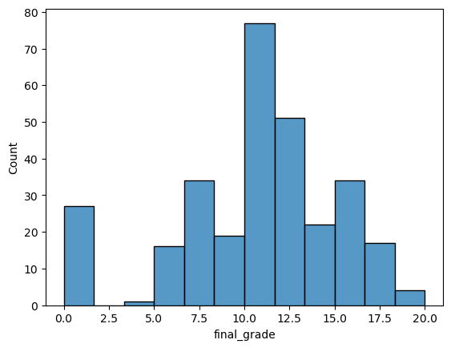

```python
sns.histplot(df['final_grade'])
plt.show()
```

```python
fiveST=[df['final_grade'].quantile(0),
df['final_grade'].quantile(0.25),
df['final_grade'].quantile(0.5),
df['final_grade'].quantile(0.75),
df['final_grade'].quantile(1)]
```

```python
fiveST# determine low the value of quartiles
```

```
[np.float64(0.0),
 np.float64(8.0),
 np.float64(11.0),
 np.float64(14.0),
 np.float64(20.0)]
```

```python
df['absences'].describe() #توضيح الغياب فقط !!!
```

```
count    302.000000
mean       6.079470
std        8.516174
min        0.000000
25%        0.000000
50%        4.000000
75%        8.000000
max       75.000000
Name: absences, dtype: float64
```

```python
df[df['absences'] > 50] #دول اعلى تلت طلاب غابوا !!!
```

|  | student_id | age | class_failures | school_support | family_support | higher_ed | internet_access | family_relationship | free_time | social | ... | travel_time_30 min. to 1 hour | travel_time_<15 min. | travel_time_>1 hour | study_time_5 to 10 hours | study_time_<2 hours | study_time_>10 hours | extra_paid_classes_yes | activities_yes | nursery_school_yes | romantic_relationship_yes |
| --- | --- | --- | --- | --- | --- | --- | --- | --- | --- | --- | --- | --- | --- | --- | --- | --- | --- | --- | --- | --- | --- |
| 61 | 75 | 16 | 0 | 1 | 1 | 1 | 1 | 4 | 3 | 3 | ... | False | True | False | False | False | False | True | True | True | False |
| 170 | 184 | 17 | 0 | 0 | 1 | 1 | 1 | 5 | 3 | 3 | ... | False | True | False | False | False | False | False | True | True | True |
| 263 | 277 | 18 | 0 | 0 | 0 | 0 | 1 | 4 | 1 | 1 | ... | False | False | False | False | False | False | False | False | False | True |

3 rows × 52 columns

```python
df['absences'] = df['absences'].clip(upper=30) #عملتلها تقييد لاقصى حد غياب و هو 30 عشان ممسحش حاجه عشان عدد الطلاب عندى 302 و ده يعتبر عدد قليل لو مسحت منه هيأثر على الداتا
```

```python
corr = df.corr()
corr['final_grade'].sort_values(ascending=False)
```

```
final_grade                                       1.000000
grade_2                                           0.919738
grade_1                                           0.802667
higher_ed                                         0.238355
mother_education_higher education                 0.217341
travel_time_<15 min.                              0.118042
father_job_teacher                                0.116608
father_education_higher education                 0.100513
sex_M                                             0.094975
address_type_Urban                                0.093454
extra_paid_classes_yes                            0.088679
mother_job_health                                 0.087979
school_choice_reason_reputation                   0.087783
nursery_school_yes                                0.083286
family_relationship                               0.077266
mother_job_teacher                                0.071595
study_time_>10 hours                              0.070642
school_choice_reason_other                        0.070570
mother_job_services                               0.068092
father_job_health                                 0.066255
activities_yes                                    0.056541
internet_access                                   0.052256
father_education_none                             0.044426
mother_education_none                             0.026393
absences                                          0.025612
guardian_mother                                   0.022830
family_size_Less than or equal to 3               0.020852
study_time_5 to 10 hours                          0.018183
father_education_secondary education              0.011962
free_time                                         0.001781
school_choice_reason_home                        -0.005696
study_time_<2 hours                              -0.027763
father_job_services                              -0.038165
travel_time_30 min. to 1 hour                    -0.050469
father_job_other                                 -0.056309
mother_job_other                                 -0.065510
travel_time_>1 hour                              -0.069276
family_support                                   -0.069330
weekday_alcohol                                  -0.071792
student_id                                       -0.072722
parent_status_Living together                    -0.078002
weekend_alcohol                                  -0.087298
mother_education_secondary education             -0.089600
guardian_other                                   -0.092304
school_support                                   -0.093508
health                                           -0.101698
father_education_primary education (4th grade)   -0.126809
age                                              -0.127966
mother_education_primary education (4th grade)   -0.141220
romantic_relationship_yes                        -0.186434
social                                           -0.206715
class_failures                                   -0.401198
Name: final_grade, dtype: float64
```

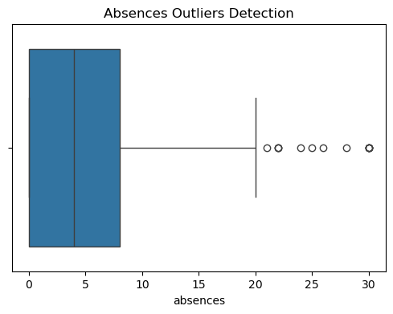

```python
plt.figure(figsize=(6,4))
sns.boxplot(x=df['absences'])
plt.title('Absences Outliers Detection')
plt.show() #بيكتشف ال outliers
```

```python
from sklearn.model_selection import train_test_split

X = df.drop('final_grade', axis=1)
y = df['final_grade']

X_train, X_test, y_train, y_test = train_test_split(
    X, y, test_size=0.2, random_state=42
) #بيبدأ يتعامل مع ال Outliers
```

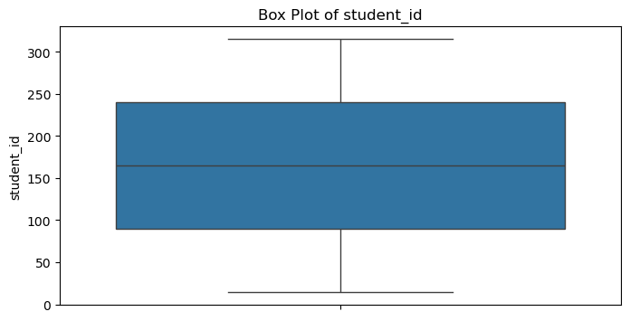

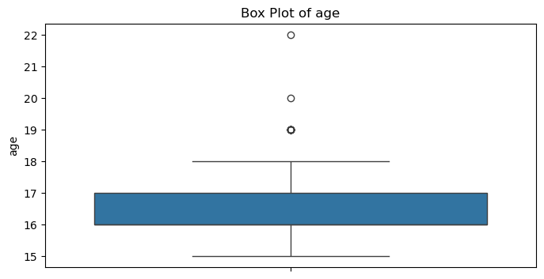

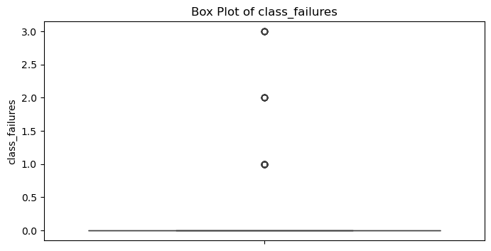

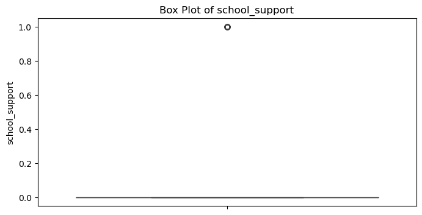

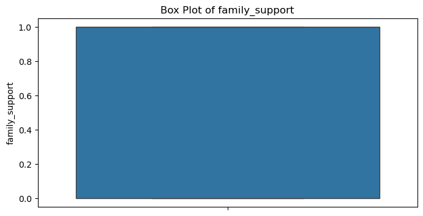

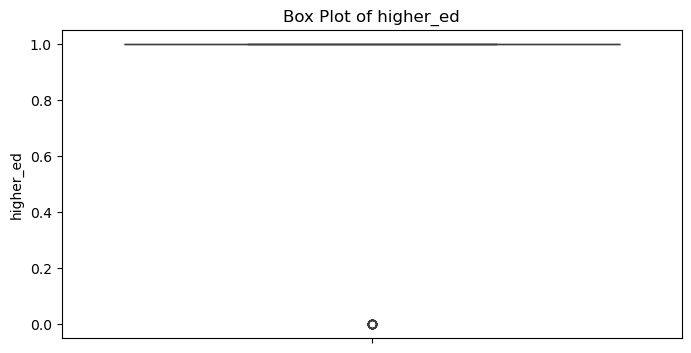

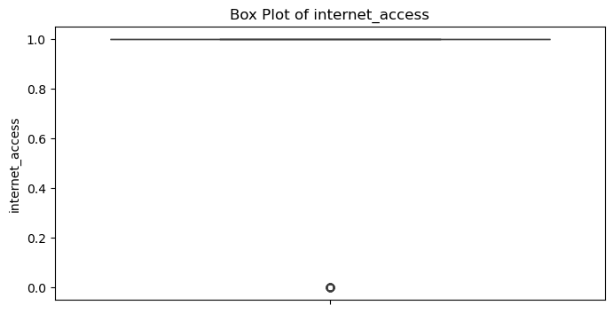

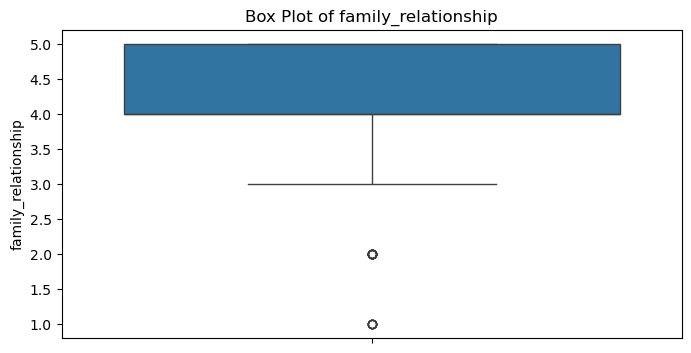

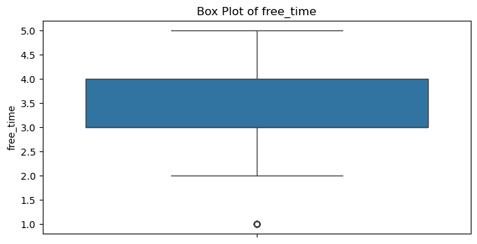

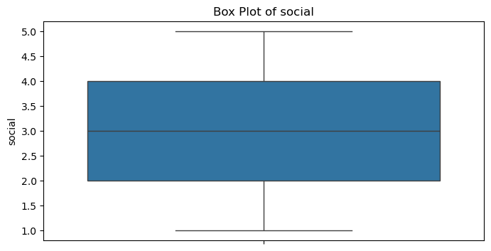

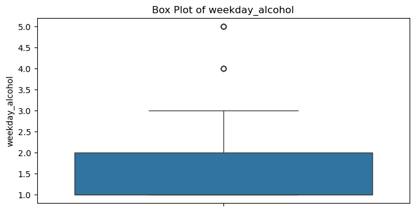

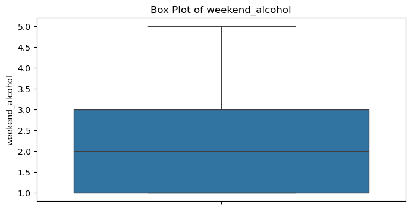

[5 more figures not shown]

```python
numerical_features = df.select_dtypes(include = 'number')

for feature in numerical_features:
    plt.figure(figsize = (8, 4))
    sns.boxplot(df[feature])
    plt.title(f'Box Plot of {feature}')
```

```python
import pandas as pd

def handle_outliers(df, columns):
    for col in columns:

        if col not in df.columns:
            continue

        if not pd.api.types.is_numeric_dtype(df[col]):
            continue

        Q1 = df[col].quantile(0.25)
        Q3 = df[col].quantile(0.75)
        IQR = Q3 - Q1

        if IQR == 0:
            continue

        lower = Q1 - 1.5 * IQR
        upper = Q3 + 1.5 * IQR

        df[col] = df[col].clip(lower, upper)

    return df
```

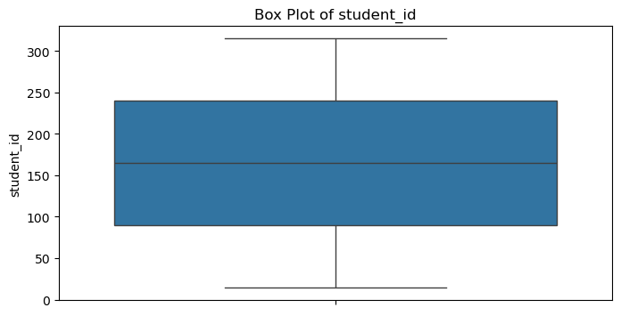

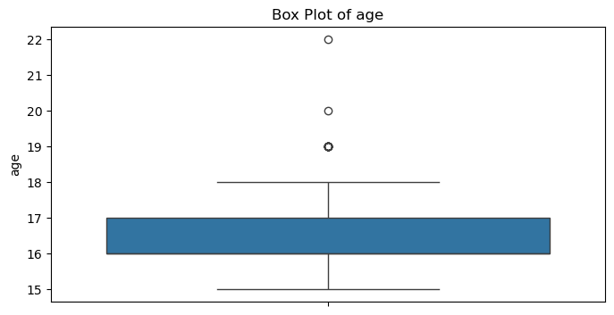

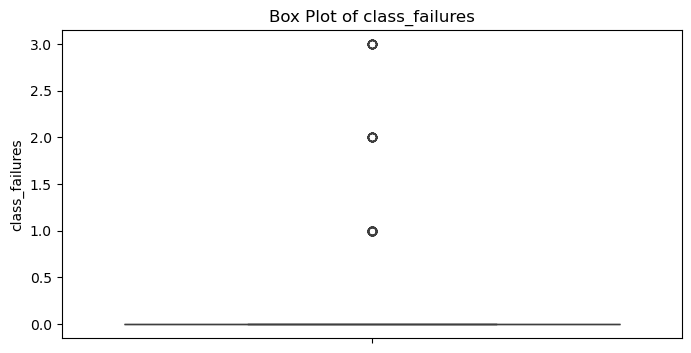

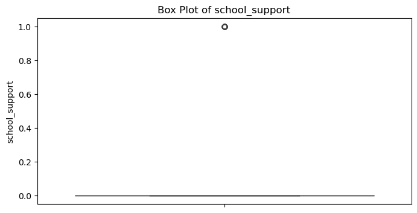

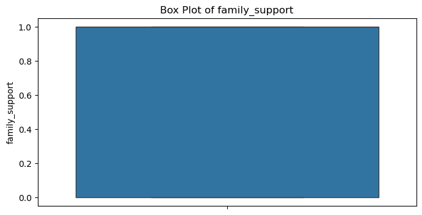

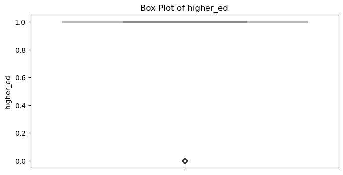

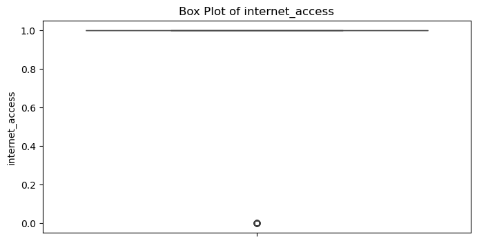

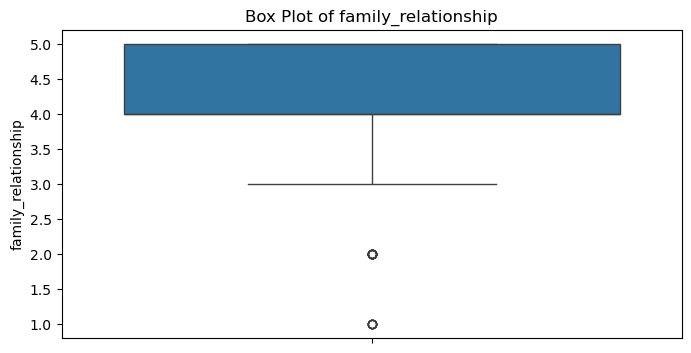

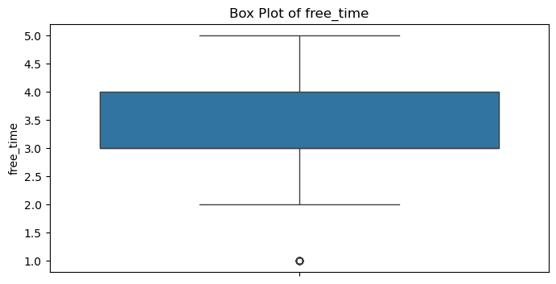

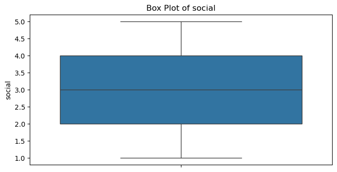

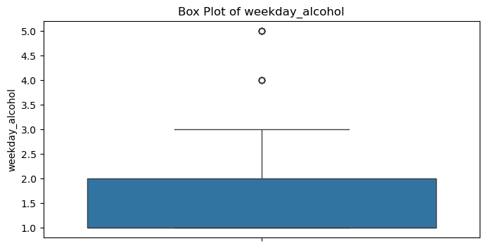

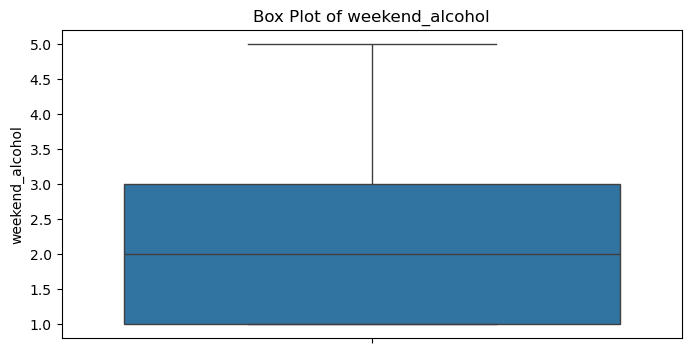

[5 more figures not shown]

```python
for feature in numerical_features:
    plt.figure(figsize = (8, 4))
    sns.boxplot(df[feature])
    plt.title(f'Box Plot of {feature}')#ده مهم جدا و بيجيب الbox blots بتاعت كل العناصر بتاعتى عشان نقدر نشوف ال Outliers
```